# **RBSI OLS and Interpretation Lab**

Mateo Villamizar-Chaparro (sv161@duke.edu)

June 2023

## **The Goal of the lab**

The goal for today is to keep learning how to use **ordinary least squares (OLS)** to analyze the relationship between variables. For this lab we are going to use a version of the 2016 ANES. A lot of you will be using this dataset for your projects so this might be helpful. In particular, we are trying to understand how participation is driven by income. You can find in Sakai a csv file called *ANES_2016* that we are going to use today. This file contains seven variables and 2762 observations from the 2016 ANES. The variables are as follows:

- *Vote*: Indicator variable if the individual casted a vote
- *Black*: Indicator variable if the individual self-identified as black
- *Hisp*: Indicator variable if the individual self-identified as hispanic
- *pid7*: 7-point partisan identification scale
- *income*: income category for the respondent
- *age*: age of the respondent at the time of the survey
- *educ_attain*: Highest educational attainment from the individual at the time of the survey.

## **First things first: Dependent and Independent variables**

For today’s aim identify:

- What is the unit of analysis?
- Which would be the independent and dependent variables of this research question.
- What would you say is the theory behind their relationship?
- What would be a hypothesis?
- What would be the mechanism?

## **Interpreting and Graphing OLS Results**:

### Remembering some of last lab’s commands

Load your data and call it `anes`. After that, create a new object called `subset_anes` that contains the variables vote, Hispanic, and educational attainment. With the `subset_anes` data create a new variable called educ_hisp that is equal to one if the individual is Hispanic and has at least a 4 in their educational attainment variable. Calculate the mean and the median of this variable. Finally, use stargazer to calculate the descriptive statistics of the ANES data.

```r
# Remember to set your working directory!
setwd("_________")

# load your data and make it in a data frame format. Always include the extension at the end of the file.
anes <- as.data.frame(_______("_______"))

# create subset_anes
vars <- c("____", "_____", "______")
sub_anes <- _____[____]

# Create the new variable educated hispanics educated means educ_attain=>4
sub_anes <- sub_anes %>% mutate(edu_hisp = ifelse(________,1,0))

# Calculate mean and median
mean_edu_hisp <- mean(sub_anes$edu_hisp)

med_edu_hisp <- median(sub_anes$edu_hisp)
```

What are the substantive meaning of these numbers?

Mean: 0.025

Median: 0

### Using `stargazer` I: Summary statistics

Stargazer is a really powerful command that can create tables, that you can then export to your papers. It is very useful that you can define a lot of the table settings. Let’s see how we can use this to display a summary statistics table.

```r
# stargazer(dataset, options)
stargazer(anes, type="text")
```

```
##
## ===========================================================
## Statistic     N    Mean  St. Dev. Min Pctl(25) Pctl(75) Max
## -----------------------------------------------------------
## vote        2,762 0.459   0.498    0     0        1      1
## black       2,762 0.105   0.307    0     0        0      1
## hisp        2,762 0.090   0.286    0     0        0      1
## pid7        2,762 3.772   2.328    1     1        6      7
## income      2,762 15.892  7.991    0     11       23    28
## age         2,762 50.616  17.097  18     36       64    89
## educ_attain 2,762 3.297   1.116    1     3        4      5
## -----------------------------------------------------------
```

```r
# What if we don¿t want to add the median?
stargazer(anes, type="text", median = TRUE)
```

```
##
## ==================================================================
## Statistic     N    Mean  St. Dev. Min Pctl(25) Median Pctl(75) Max
## ------------------------------------------------------------------
## vote        2,762 0.459   0.498    0     0       0       1      1
## black       2,762 0.105   0.307    0     0       0       0      1
## hisp        2,762 0.090   0.286    0     0       0       0      1
## pid7        2,762 3.772   2.328    1     1       3       6      7
## income      2,762 15.892  7.991    0     11      17      23    28
## age         2,762 50.616  17.097  18     36      52      64    89
## educ_attain 2,762 3.297   1.116    1     3       3       4      5
## ------------------------------------------------------------------
```

```r
# You can play with some of the other values in order for the to appear or not in the table: nobs, mean.sd, iqr, etc
# You can also display the statistics you want using a list object but the names are different
stargazer(anes, type="text", summary.stat = c("n", "min", "mean", "max", "sd")) # order matters here
```

```
##
## =========================================
## Statistic     N   Min  Mean  Max St. Dev.
## -----------------------------------------
## vote        2,762  0  0.459   1   0.498
## black       2,762  0  0.105   1   0.307
## hisp        2,762  0  0.090   1   0.286
## pid7        2,762  1  3.772   7   2.328
## income      2,762  0  15.892 28   7.991
## age         2,762 18  50.616 89   17.097
## educ_attain 2,762  1  3.297   5   1.116
## -----------------------------------------
```

```r
# You can also change the names of the covariates to more descriptive ones (order matters here too!!)
stargazer(anes, type="text", summary.stat = c("n", "min", "mean", "max", "sd"),
           covariate.labels=c("Voted 2016 election","Respondent is Black","Respondent is Hispanic", "PArty Identification", "Income", "Age", "Educational attainment"))
```

```
##
## ====================================================
## Statistic                N   Min  Mean  Max St. Dev.
## ----------------------------------------------------
## Voted 2016 election    2,762  0  0.459   1   0.498
## Respondent is Black    2,762  0  0.105   1   0.307
## Respondent is Hispanic 2,762  0  0.090   1   0.286
## PArty Identification   2,762  1  3.772   7   2.328
## Income                 2,762  0  15.892 28   7.991
## Age                    2,762 18  50.616 89   17.097
## Educational attainment 2,762  1  3.297   5   1.116
## ----------------------------------------------------
```

```r
# What about adding a name and making the number of digits after zero smaller?
stargazer(anes, type="text", summary.stat = c("n", "min", "mean", "max", "sd"),
           covariate.labels=c("Voted 2016 election","Respondent is Black","Respondent is Hispanic", "PArty Identification", "Income", "Age", "Educational attainment"),
          title="Descriptive statistics/selected variables",
          digits=2)
```

```
##
## Descriptive statistics/selected variables
## ===================================================
## Statistic                N   Min Mean  Max St. Dev.
## ---------------------------------------------------
## Voted 2016 election    2,762  0  0.46   1    0.50
## Respondent is Black    2,762  0  0.11   1    0.31
## Respondent is Hispanic 2,762  0  0.09   1    0.29
## PArty Identification   2,762  1  3.77   7    2.33
## Income                 2,762  0  15.89 28    7.99
## Age                    2,762 18  50.62 89   17.10
## Educational attainment 2,762  1  3.30   5    1.12
## ---------------------------------------------------
```

```r
# Finally, how can you export it
stargazer(anes, type="text", summary.stat = c("n", "min", "mean", "max", "sd"),
           covariate.labels=c("Voted 2016 election","Respondent is Black","Respondent is Hispanic", "PArty Identification", "Income", "Age", "Educational attainment"),
          title="Descriptive statistics/selected variables",
          digits=2,
          out="desc_stats.doc")
```

```
##
## Descriptive statistics/selected variables
## ===================================================
## Statistic                N   Min Mean  Max St. Dev.
## ---------------------------------------------------
## Voted 2016 election    2,762  0  0.46   1    0.50
## Respondent is Black    2,762  0  0.11   1    0.31
## Respondent is Hispanic 2,762  0  0.09   1    0.29
## PArty Identification   2,762  1  3.77   7    2.33
## Income                 2,762  0  15.89 28    7.99
## Age                    2,762 18  50.62 89   17.10
## Educational attainment 2,762  1  3.30   5    1.12
## ---------------------------------------------------
```

### Interpretations

In our model, we are using a dichotomous dependent variable. Thus, the “units” will be know as **percentage points** which is different to percentages. Also, unless you have a causal framework it is better to talk about correlations and not clear effects. Finally, all interpretations are under the assumption that all the other parts of the model remain constant (ceteris paribus).

For this part of the lab, we will run a **linear probability model (LPM)**. Logit and probit models can also be used to estimate dichotomous variables. However, for ease of interpretation, we will be going with an LPM. If you want to know more about logit and probit models send Gloria or me an email message.

Run a first model that shows the correlation between voting and being Black and Hispanic. Then run another model that includes partisan identification, income, age and educational attainment as controls. Create a stargazer table for both models where only the racial categories appear.

```r
# Run your first model
m1 <- ___(vote ~ __ + ____, _____ = anes)

# Run your second model
m2 <- ___(____________________________________, _______ = anes)
```

What model would you choose to present and why?

### An aside using `stargazer` II: Regression tables and choosing between models

This last section will focus on how to compare across models and how to export this output using `stargazer`. Let’s first understand how stargazer works. I found this stargazer [webpage](https://www.jakeruss.com/cheatsheets/stargazer/#omit-parts-of-the-default-output) very useful.

```r
# Using stargazer for getting a summary of the regression
stargazer(m1, m2, type="text")
```

```
##
## =======================================================================
##                                     Dependent variable:
##                     ---------------------------------------------------
##                                            vote
##                                (1)                       (2)
## -----------------------------------------------------------------------
## hisp                        -0.326***                 -0.148***
##                              (0.031)                   (0.020)
##
## black                       -0.516***                 -0.148***
##                              (0.029)                   (0.020)
##
## educ_attain                                           -0.035***
##                                                        (0.006)
##
## pid7                                                  0.161***
##                                                        (0.003)
##
## income                                                -0.002**
##                                                        (0.001)
##
## age                                                   0.001***
##                                                       (0.0003)
##
## Constant                    0.543***                   -0.027
##                              (0.010)                   (0.029)
##
## -----------------------------------------------------------------------
## Observations                  2,762                     2,762
## R2                            0.123                     0.652
## Adjusted R2                   0.123                     0.651
## Residual Std. Error     0.467 (df = 2759)         0.294 (df = 2755)
## F Statistic         193.905*** (df = 2; 2759) 860.889*** (df = 6; 2755)
## =======================================================================
## Note:                                       *p<0.1; **p<0.05; ***p<0.01
```

```r
# Add title and covariate labels
stargazer(m1, m2, type="text",
          title            = "Table 1",                          # Give a title to the table
          covariate.labels = c("Hispanic", "Black"))             # Choose the labels for the variables you want to show
```

```
##
## Table 1
## =======================================================================
##                                     Dependent variable:
##                     ---------------------------------------------------
##                                            vote
##                                (1)                       (2)
## -----------------------------------------------------------------------
## Hispanic                    -0.326***                 -0.148***
##                              (0.031)                   (0.020)
##
## Black                       -0.516***                 -0.148***
##                              (0.029)                   (0.020)
##
## educ_attain                                           -0.035***
##                                                        (0.006)
##
## pid7                                                  0.161***
##                                                        (0.003)
##
## income                                                -0.002**
##                                                        (0.001)
##
## age                                                   0.001***
##                                                       (0.0003)
##
## Constant                    0.543***                   -0.027
##                              (0.010)                   (0.029)
##
## -----------------------------------------------------------------------
## Observations                  2,762                     2,762
## R2                            0.123                     0.652
## Adjusted R2                   0.123                     0.651
## Residual Std. Error     0.467 (df = 2759)         0.294 (df = 2755)
## F Statistic         193.905*** (df = 2; 2759) 860.889*** (df = 6; 2755)
## =======================================================================
## Note:                                       *p<0.1; **p<0.05; ***p<0.01
```

```r
# Adding captions for the dependent variable and the type of model
stargazer(m1, m2, type="text",
          title            = "Table 1",                          # Give a title to the table
          covariate.labels = c("Hispanic", "Black"),             # Choose the labels for the variables you want to show
          dep.var.caption  = "OLS Models",                       # Name your columns
          dep.var.labels   = "Voted")                            # Name your dependent variable
```

```
##
## Table 1
## =======================================================================
##                                         OLS Models
##                     ---------------------------------------------------
##                                            Voted
##                                (1)                       (2)
## -----------------------------------------------------------------------
## Hispanic                    -0.326***                 -0.148***
##                              (0.031)                   (0.020)
##
## Black                       -0.516***                 -0.148***
##                              (0.029)                   (0.020)
##
## educ_attain                                           -0.035***
##                                                        (0.006)
##
## pid7                                                  0.161***
##                                                        (0.003)
##
## income                                                -0.002**
##                                                        (0.001)
##
## age                                                   0.001***
##                                                       (0.0003)
##
## Constant                    0.543***                   -0.027
##                              (0.010)                   (0.029)
##
## -----------------------------------------------------------------------
## Observations                  2,762                     2,762
## R2                            0.123                     0.652
## Adjusted R2                   0.123                     0.651
## Residual Std. Error     0.467 (df = 2759)         0.294 (df = 2755)
## F Statistic         193.905*** (df = 2; 2759) 860.889*** (df = 6; 2755)
## =======================================================================
## Note:                                       *p<0.1; **p<0.05; ***p<0.01
```

```r
# Add lines to the table, keep only certain variables
stargazer(m1, m2, type="text",
          title            = "Table 1",                          # Give a title to the table
          covariate.labels = c("Hispanic", "Black"),             # Choose the labels for the variables you want to show
          dep.var.caption  = "OLS Models",                       # Name your columns
          dep.var.labels   = "Voted",                            # Name your dependent variable
          add.lines = list(c("Controls", "No", "Yes")),          # add lines of info
          keep = c("black","hisp"))                              # keep certain variables
```

```
##
## Table 1
## =======================================================================
##                                         OLS Models
##                     ---------------------------------------------------
##                                            Voted
##                                (1)                       (2)
## -----------------------------------------------------------------------
## Hispanic                    -0.326***                 -0.148***
##                              (0.031)                   (0.020)
##
## Black                       -0.516***                 -0.148***
##                              (0.029)                   (0.020)
##
## -----------------------------------------------------------------------
## Controls                       No                        Yes
## Observations                  2,762                     2,762
## R2                            0.123                     0.652
## Adjusted R2                   0.123                     0.651
## Residual Std. Error     0.467 (df = 2759)         0.294 (df = 2755)
## F Statistic         193.905*** (df = 2; 2759) 860.889*** (df = 6; 2755)
## =======================================================================
## Note:                                       *p<0.1; **p<0.05; ***p<0.01
```

```r
# Exporting the data
stargazer(m1, m2, type="text",
          title            = "Table 1",                          # Give a title to the table
          covariate.labels = c("Hispanic", "Black"),             # Choose the labels for the variables you want to show
          dep.var.caption  = "OLS Models",                       # Name your columns
          dep.var.labels   = "Voted",                            # Name your dependent variable
          add.lines = list(c("Controls", "No", "Yes")),          # add lines of info
          keep = c("black","hisp"),                              # keep certain variables
          out="table1.doc")                                      # for nicer looking exported tables change text for html in type
```

```
##
## Table 1
## =======================================================================
##                                         OLS Models
##                     ---------------------------------------------------
##                                            Voted
##                                (1)                       (2)
## -----------------------------------------------------------------------
## Hispanic                    -0.326***                 -0.148***
##                              (0.031)                   (0.020)
##
## Black                       -0.516***                 -0.148***
##                              (0.029)                   (0.020)
##
## -----------------------------------------------------------------------
## Controls                       No                        Yes
## Observations                  2,762                     2,762
## R2                            0.123                     0.652
## Adjusted R2                   0.123                     0.651
## Residual Std. Error     0.467 (df = 2759)         0.294 (df = 2755)
## F Statistic         193.905*** (df = 2; 2759) 860.889*** (df = 6; 2755)
## =======================================================================
## Note:                                       *p<0.1; **p<0.05; ***p<0.01
```

### Dichotomous and continuous variables

Let’s first understand a bit mote how the results from `summary` are presented in the `stargazer` tables.

```
##
## Call:
## lm(formula = vote ~ hisp + black + educ_attain + pid7 + income +
##     age, data = anes)
##
## Residuals:
##      Min       1Q   Median       3Q      Max
## -1.09073 -0.11941 -0.00022  0.13576  1.10610
##
## Coefficients:
##               Estimate Std. Error t value Pr(>|t|)
## (Intercept) -0.0268481  0.0286790  -0.936  0.34927
## hisp        -0.1480181  0.0203096  -7.288 4.09e-13 ***
## black       -0.1483469  0.0198518  -7.473 1.05e-13 ***
## educ_attain -0.0352180  0.0055525  -6.343 2.63e-10 ***
## pid7         0.1613291  0.0025796  62.540  < 2e-16 ***
## income      -0.0018957  0.0007788  -2.434  0.01499 *
## age          0.0010460  0.0003322   3.149  0.00166 **
## ---
## Signif. codes:  0 '***' 0.001 '**' 0.01 '*' 0.05 '.' 0.1 ' ' 1
##
## Residual standard error: 0.2943 on 2755 degrees of freedom
## Multiple R-squared:  0.6522, Adjusted R-squared:  0.6514
## F-statistic: 860.9 on 6 and 2755 DF,  p-value: < 2.2e-16
```

```
##
## ===============================================
##                         Dependent variable:
##                     ---------------------------
##                                vote
## -----------------------------------------------
## hisp                         -0.148***
##                               (0.020)
##
## black                        -0.148***
##                               (0.020)
##
## educ_attain                  -0.035***
##                               (0.006)
##
## pid7                         0.161***
##                               (0.003)
##
## income                       -0.002**
##                               (0.001)
##
## age                          0.001***
##                              (0.0003)
##
## Constant                      -0.027
##                               (0.029)
##
## -----------------------------------------------
## Observations                   2,762
## R2                             0.652
## Adjusted R2                    0.651
## Residual Std. Error      0.294 (df = 2755)
## F Statistic          860.889*** (df = 6; 2755)
## ===============================================
## Note:               *p<0.1; **p<0.05; ***p<0.01
```

### Looking at the results Graphically

#### Canned functions

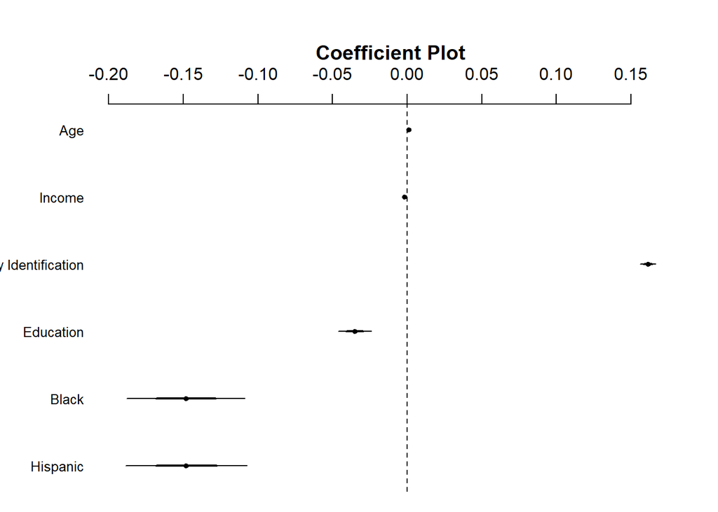

Let’s run a new model and graph it’s results.

```r
m3 <- _______________

________ (______,
          intercept = ____,
          main = "__________",
          variables = _("___", "_____", "______"))
```

#### Using ggplot (more next class)

For most coefplots, we will need to create a placeholder matrix and then use the graphing functions and attributes we have seen. You can also use base R instead of `coefplot` to produce these kind of graphs. If you are interested in learning how to do this. Let us know and we can go through some code together. This placeholder matrix will be a “small dataset” with the coefficients, standard errors and confidence intervals to graph later.

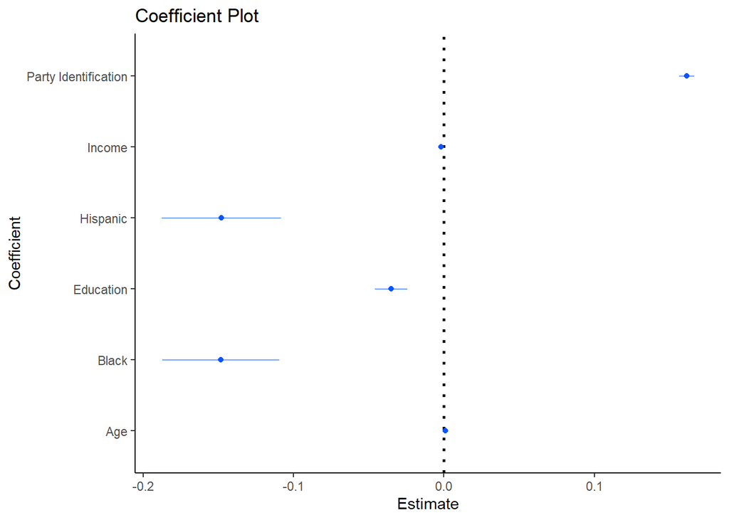

I prefer to use ggplot or basic R since it is easier to customize than coefplot.

## **Interactions**

3. **Effects of interactions:** You can also have a model with an interaction. This will make interpretation a bit trickier. For this section, let’s simplify our model and analyze the probability of voting with respect to being hispanic, the education level of the individual and their interaction. Here, we could hypothesize that more educated hispanics will vote more. The model we want to estimate is:

$$vote_i = \beta_0 +\beta_1hisp_i +
\beta_2 educ_i + \beta_3 hisp_i\times educ_i + \epsilon_i$$
In this case:

Let’s run and interpret another interaction model between being Hispanic and education.

```r
m4 <- ___(_____)
summary(m4)
```

```
##
## Call:
## lm(formula = vote ~ hisp * educ_attain, data = anes)
##
## Residuals:
##     Min      1Q  Median      3Q     Max
## -0.6435 -0.4383 -0.2183  0.4933  0.8047
##
## Coefficients:
##                  Estimate Std. Error t value Pr(>|t|)
## (Intercept)       0.71188    0.03095  23.001  < 2e-16 ***
## hisp             -0.52814    0.08941  -5.907 3.91e-09 ***
## educ_attain      -0.06840    0.00880  -7.773 1.07e-14 ***
## hisp:educ_attain  0.07992    0.02851   2.803   0.0051 **
## ---
## Signif. codes:  0 '***' 0.001 '**' 0.01 '*' 0.05 '.' 0.1 ' ' 1
##
## Residual standard error: 0.4875 on 2758 degrees of freedom
## Multiple R-squared:  0.04447,    Adjusted R-squared:  0.04343
## F-statistic: 42.79 on 3 and 2758 DF,  p-value: < 2.2e-16
```

## **Predictions and Marginal Effects**

Interpreting interaction effects can be hard. The easiest way is to show the marginal changes visually. In other words, we can plot the effects of interactions. These are usually known as **marginal effect plots**. For this, we can use a combination of `ggplot` and `ggeffects` or use base R. We would look at this on the next lab. For today, I want to explain a bit more what the `predict` command does and how it is helpful to deal with interactions.

### Why predict?

The goal of running statistical models is not only identifying the correlations between variables but, in some cases, use this information to generate predictions. Recent machine learning models use predictions from statistical models to recommend you songs (i.e. Spotify), shows (i.e. Netflix). What people sometimes call the *algorithm* is just how the predictions are made. We can use our regression estimates to predict the probability of voting of the people in our sample. In this case, we would be calculating:

$$\hat{vote_i} = \hat{\beta_0}
+\hat{\beta_1} hisp_i + \hat{\beta_2} edu_i + \hat{\beta_3} hisp_i\times
edu_i$$

```r
m4 <- lm(vote ~ hisp*educ_attain, data = sub_anes)
# Initial data
head(as.data.frame(sub_anes))
```

```
##   vote hisp educ_attain edu_hisp
## 1    1    0           2        0
## 2    1    0           4        0
## 3    0    0           1        0
## 4    1    0           2        0
## 5    0    0           3        0
## 6    1    0           3        0
```

```r
# Predict command
sub_anes$pred_data <- predict(m4,                     # model used
                              type="response")        # type of response, see ?predict for multiple outputs
# Final look of the dataset
head(as.data.frame(sub_anes))
```

```
##   vote hisp educ_attain edu_hisp pred_data
## 1    1    0           2        0 0.5750763
## 2    1    0           4        0 0.4382758
## 3    0    0           1        0 0.6434766
## 4    1    0           2        0 0.5750763
## 5    0    0           3        0 0.5066761
## 6    1    0           3        0 0.5066761
```

If we were to plot the predicted effects we would something like this:

[figure not shown]

## **The new functions we used today**

- ggplot()
- predict()
- coefplot()
- ggeffects()

## **Some additional resources**

1. There is a whole art behind visualization and making graphs in R. Here are some links that might be useful when producing different visualizations of your data.
   - I found the Computational Social Science webpages from [Tiago Ventura](https://tiagoventura.rbind.io/teaching/), [Yae Jeon Kim](https://jaeyk.github.io/PS239T/) and Summer Institute of Computational Social Science [(SICSS)](https://sicss.io/boot_camp) useful for the elaboration of this lab. Some of the examples are the same and others are inspired on them.
   - I also highly recommend Kieran Healy’s [book](https://socviz.co/index.html#preface) on Data Visualization using ggplot.
   - There is also a ggplot [cheat sheet](https://github.com/rstudio/cheatsheets/blob/master/data-visualization-2.1.pdf) that is always handy.
   - Here are some ggplot visualization [examples](http://r-statistics.co/Top50-Ggplot2-Visualizations-MasterList-R-Code.html)